# Exercícios Aula 9 - Testes Estatísticos e Regressões

Beatriz Milz

08/05/2020

```r
library(tidyverse)
library(nycflights13)
library(broom)
library(stargazer)
library(Zelig)
options(scipen=999)
```

## Exercício 1: Testes Estatísticos

1. Use a função rnorm(1000, 0, 1) para gerar um vetor de 1000 observações aleatoriamente da distribuição normal. Avalie se os valores gerados sejam realmente distribuido normal com um teste Shapiro-Wilk.

**Teste de normalidade**

```r
rnorm(1000, 0, 1) %>%
  shapiro.test() %>%
  broom::tidy()
```

| statistic | p.value | method |
| --- | --- | --- |
| 0.9988028 | 0.7566952 | Shapiro-Wilk normality test |

2. No banco de dados planes, teste se o ano de fabricação dos voos de fabricador Boeing seja diferente de 2000.

**Teste de média**

```r
teste_media_2 <- planes %>%
  filter(manufacturer == "BOEING") %>%
  pull(year) %>%
  t.test(mu = 2000) %>%
  tidy()
```

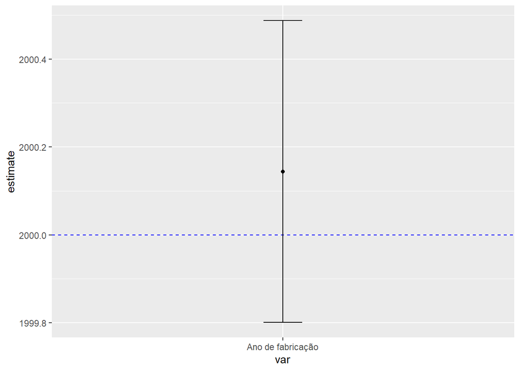

```r
teste_media_2 %>% mutate(var = "Ano de fabricação") %>%
  ggplot() +
  geom_point(aes(x = var, y = estimate)) +
  geom_hline(yintercept = 2000, lty=2, color = "blue") +
  geom_errorbar(aes(x = var, ymin = conf.low, ymax = conf.high), width = 0.1)
```

**R:** Não é diferente.

3. Avalie com um teste apropriado se a velocidade média de voos de Newark (EWR) seja igual a velocidade de vôos de LaGuardia (LGA). (Lembre-se que tem que calcular velocidade).

**Comparar médias**

```r
flights %>%
  mutate(velocidade = distance/air_time) %>%
  filter(origin %in% c("LGA", "EWR")) %>%
  t.test(velocidade ~ origin, data = .) %>%
  tidy()
```

| estimate | estimate1 | estimate2 | statistic | p.value | parameter | conf.low | conf.high | method | alternative |
| --- | --- | --- | --- | --- | --- | --- | --- | --- | --- |
| 0.136811 | 6.599225 | 6.462414 | 34.73691 | 0.000000000000000000000000000000000000000000000000000000000000000000000000000000000000000000000000000000000000000000000000000000000000000000000000000000000000000000000000000000000000000000000000000000… | 214920.2 | 0.1290916 | 0.1445303 | Welch Two Sample t-test | two.sided |

4. Usando o banco de dados weather, qual é a correlação entre temperatura e pressão?

```r
cor.test(~ temp + pressure, data = weather)
```

```
##
##  Pearson's product-moment correlation
##
## data:  temp and pressure
## t = -39.881, df = 23384, p-value < 0.00000000000000022
## alternative hypothesis: true correlation is not equal to 0
## 95 percent confidence interval:
##  -0.2643212 -0.2403201
## sample estimates:
##        cor
## -0.2523595
```

5. Crie um gráfico usando geom_errorbar() para comunicar o intervalo de confiança da estimativa de correlação em questão 4. Adicione uma linha horizontal para comparar com uma correlação de zero.

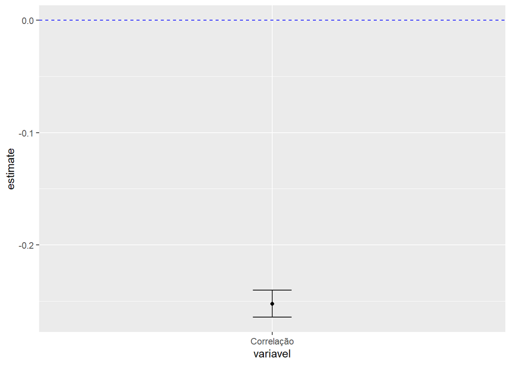

```r
# Não consegui terminar esse, olhei na resolução da aula. Não entendi pq filtra o origin, pois não é solicitado no exercício. Não filtrei.

cor.test( ~ temp + pressure, data = weather) %>%
  tidy() %>%
  mutate(variavel = "Correlação") %>%
  ggplot() +
  geom_point(aes(x = variavel, y = estimate)) +
  geom_hline(yintercept = 0,
             lty = 2,
             color = "blue") +
  geom_errorbar(aes(x = variavel, ymin = conf.low, ymax = conf.high),
                width = 0.1)
```

## Exercício 2: Regressões

1. Usando uma regressão linear, qual é a associação entre precipitação (variável dependente) e as três variáveis pressão, temperatura e humidade no banco de dados weather? Qual dessas três variáveis tem relacionamente positivo com a variável dependente, e qual um relationamento negativo?

```r
# y = precipitação

lm_1 <- lm(precip ~ pressure + temp + humid, weather)

lm_1
```

```
##
## Call:
## lm(formula = precip ~ pressure + temp + humid, data = weather)
##
## Coefficients:
## (Intercept)     pressure         temp        humid
##  0.18621024  -0.00018646  -0.00005877   0.00014266
```

**R:** A variável umidade tem relacão positiva com a precipitação, e as variável pressão e temperatura tem relação negativa.

2. Rode mais um modelo de regressão adicionando mais uma variável explicativa para o aeroporto de origin ao modelo de questão 1. Mostre os seus dois modelos juntos numa tabela apropriada.

```r
# y = precipitação

lm_2 <- lm(precip ~ pressure + temp + humid + wind_speed, weather)



lm_2
```

```
##
## Call:
## lm(formula = precip ~ pressure + temp + humid + wind_speed, data = weather)
##
## Coefficients:
## (Intercept)     pressure         temp        humid   wind_speed
##  0.16370336  -0.00016602  -0.00005302   0.00015150   0.00008201
```

```r
list(lm_1, lm_2) %>% stargazer(type = "html", align = TRUE)
```

|  | *Dependent variable:* |  |
| --- | --- | --- |
|  | precip |  |
|  | (1) | (2) |
| pressure | -0.0002*** | -0.0002*** |
|  | (0.00001) | (0.00001) |
| temp | -0.0001*** | -0.0001*** |
|  | (0.00001) | (0.00001) |
| humid | 0.0001*** | 0.0002*** |
|  | (0.00001) | (0.00001) |
| wind_speed |  | 0.0001*** |
|  |  | (0.00001) |
| Constant | 0.186*** | 0.164*** |
|  | (0.014) | (0.014) |
| Observations | 23,386 | 23,383 |
| R<sup>2</sup> | 0.045 | 0.048 |
| Adjusted R<sup>2</sup> | 0.045 | 0.047 |
| Residual Std. Error | 0.014 (df = 23382) | 0.014 (df = 23378) |
| F Statistic | 370.511*** (df = 3; 23382) | 291.811*** (df = 4; 23378) |
| *Note:* | p<0.1; p<0.05; p<0.01 |  |

3. Crie um gráfico de efeitos marginais para a sua regressão na questão 2.

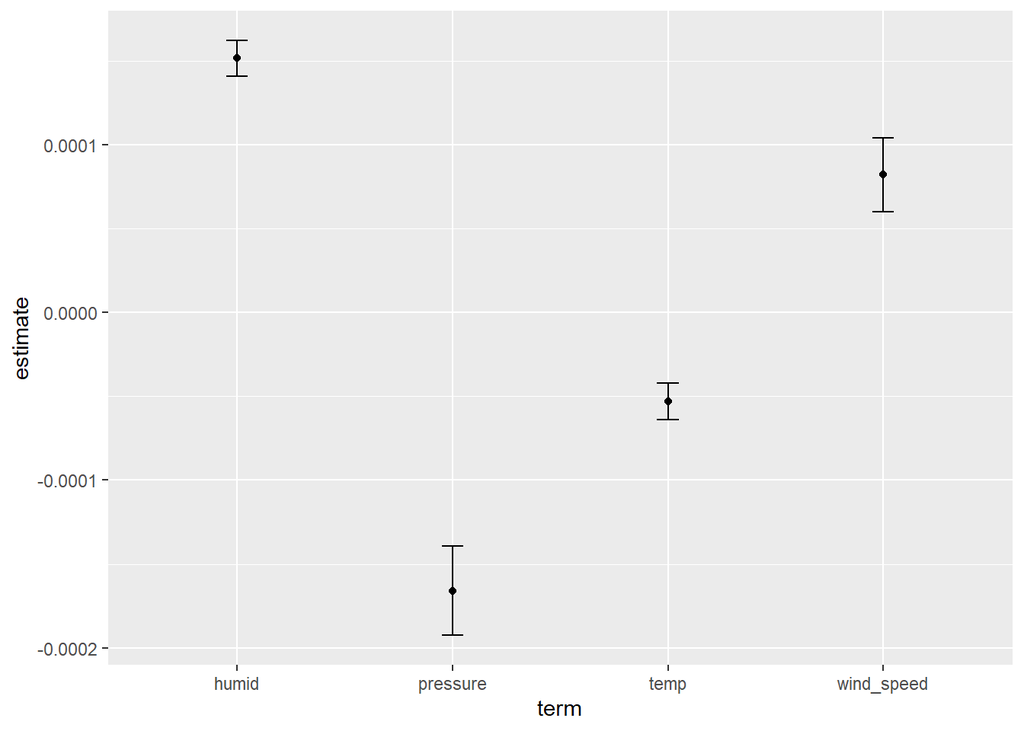

```r
lm_2 %>% tidy() %>%
  mutate(conf.lo = estimate - 1.96 * std.error,
         conf.hi = estimate + 1.96 * std.error) %>%
  filter(term != "(Intercept)") %>%
  ggplot() +
  geom_point(aes(x = term, y = estimate)) +
  geom_errorbar(aes(
    x = term,
    y = estimate,
    ymin = conf.lo,
    ymax = conf.hi
  ), width = 0.1)
```

4. Execute uma regressão do tipo ‘logit’ que explica se um vôo dure mais de três horas ou não (gere esta variável) baseado nas variáveis ‘dep_time’, ‘distance’ e ‘origin’.

```r
modelo_3h <- flights %>%
  mutate(mais_de_3h = air_time > 180,
         origin = as.factor(origin)) %>%
  zelig(mais_de_3h ~ dep_time + distance + origin, data = ., model = "logit")
```

How to cite this model in Zelig: R Core Team. 2007. logit: Logistic Regression for Dichotomous Dependent Variables in Christine Choirat, Christopher Gandrud, James Honaker, Kosuke Imai, Gary King, and Olivia Lau, “Zelig: Everyone’s Statistical Software,” http://zeligproject.org/

```r
modelo_3h %>%
  from_zelig_model() %>%
  stargazer(type="html")
```

|  | *Dependent variable:* |
| --- | --- |
|  | mais_de_3h |
| dep_time | 0.00005 |
|  | (0.00003) |
| distance | 0.016*** |
|  | (0.0001) |
| originJFK | -0.170*** |
|  | (0.043) |
| originLGA | -0.006 |
|  | (0.034) |
| Constant | -20.928*** |
|  | (0.132) |
| Observations | 327,346 |
| Log Likelihood | -16,753.300 |
| Akaike Inf. Crit. | 33,516.600 |
| *Note:* | p<0.1; p<0.05; p<0.01 |

5. Use a sua regressão de questão 4 e as funções de Zelig para prever quanto mais provável é que um vôo seja mais de três horas de duração quando a distância aumenta de 700 para 1300 kilometros.

```r
modelo_3h %>%
  setx(distance=700) %>%
  setx1(distance=1300) %>%
  sim()
```

```
##
##  sim x :
##  -----
## ev
##               mean             sd           50%          2.5%         97.5%
## [1,] 0.00007860375 0.000004664503 0.00007837297 0.00007011462 0.00008809354
## pv
##          0     1
## [1,] 0.999 0.001
##
##  sim x1 :
##  -----
## ev
##           mean          sd       50%      2.5%     97.5%
## [1,] 0.5818293 0.005913953 0.5817259 0.5703917 0.5936452
## pv
##          0     1
## [1,] 0.409 0.591
## fd
##           mean          sd       50%      2.5%     97.5%
## [1,] 0.5817507 0.005912645 0.5816423 0.5703212 0.5935641
```